# Overview

My Fitbit history data was exported from my Fitbit Dashboard.  
The goal is to use this data to understand personal fitness habits and trends.

Date Range of Data

- I purchased my 1st device Tuesday, August 20, 2019.
- I purchased my 2nd device Monday, June 21, 2021
- I exported my data on Saturday July 17, 2021

For now, the data I will work with is from 2020 as it is the only complete year of data available.

Directory Structure of the Fitbit Data:  
/Physical Activity

From here I create separate directories for each data set type.

- Steps
- Distance
- Calories
- etc

There are many separate JSON files for each data set. For example, for steps data, 1 example filename is steps-2019-08-21.json.

- I collect all files with this name structure, and create a new separate directory to hold them.
- Then, I load each individual json files into its own dataframe
- Then, I create a list of all dataframes that have been appended to each other
- Then, I create 1 dataframe from that list.

This process is repeated for all different data sets/directories.

## Resources

https://medium.com/analytics-vidhya/exploring-your-fitbit-sleep-data-with-python-pandas-and-seaborn-in-jupyter-notebook-a997f17c3a42

https://towardsdatascience.com/formating-and-visualizing-time-series-data-ba0b2548f27b

https://github.com/CoreyMSchafer/code_snippets/blob/master/Python/Pandas/10-Datetime-Timeseries/Pandas-Demo.ipynb

https://github.com/soumilshah1995/Data-Analysis-Over-10-years-of-hourly-energy-consumption-data-from-PJM-in-Megawatts/blob/master/Exp3%20.ipynb

# Import Packages

```python
import os
import pandas as pd
import numpy as np
import seaborn as sns
import glob
import shutil

from IPython.core.interactiveshell import InteractiveShell
InteractiveShell.ast_node_interactivity = "all"

import matplotlib.pyplot as plt
import seaborn as sns
from pandas.plotting import register_matplotlib_converters

%matplotlib inline
```

# Data Wrangling

```python
os.getcwd()
```

```
'c:\\Users\\Brandi\\Documents\\Data Projects\\my-data-story'
```

```python
os.chdir('c:\\Users\\Brandi\\Documents\\my_fitbit_data\\Physical_Activity')
os.getcwd()
```

```
'c:\\Users\\Brandi\\Documents\\my_fitbit_data\\Physical_Activity'
```

```python
# to be run only once.
# #to list collection of unique file names without timestamp

# filenames = os.listdir()

# print(f"Parsing {len(filenames)} files for unique types.")
# unique_filenames = set()
# for f in filenames:
#     unique_filenames.add(f.split("-")[0])
# print(f"Found {len(unique_filenames)} unique types.")
# for name in sorted(unique_filenames):
#     print(name)
```

```python
# to be run only once.
# create new directory with relative path.
# move similarly names files to new directory

# os.mkdir(os.path.join(".","steps_data"))
# dest_dir = os.path.join(".","steps_data")
# for file in glob.glob('steps*'):
#     shutil.move(file, dest_dir)

# os.mkdir(os.path.join(".","distance_data"))
# dest_dir = os.path.join(".","distance_data")
# for file in glob.glob('distance*'):
#     shutil.move(file, dest_dir)

# os.mkdir(os.path.join(".","calories_data"))
# dest_dir = os.path.join(".","calories_data")
# for file in glob.glob('calories*'):
#     shutil.move(file, dest_dir)

# os.mkdir(os.path.join(".","heart_rate_data"))
# dest_dir = os.path.join(".","heart_rate_data")
# for file in glob.glob('heart_rate*'):
#     shutil.move(file, dest_dir)

# os.mkdir(os.path.join(".","lightly_active_minutes_data"))
# dest_dir = os.path.join(".","lightly_active_minutes_data")
# for file in glob.glob('lightly*'):
#     shutil.move(file, dest_dir)

# os.mkdir(os.path.join(".","moderately_active_minutes_data"))
# dest_dir = os.path.join(".","moderately_active_minutes_data")
# for file in glob.glob('moderately*'):
#     shutil.move(file, dest_dir)

# os.mkdir(os.path.join(".","sedentary_minutes_data"))
# dest_dir = os.path.join(".","sedentary_minutes_data")
# for file in glob.glob('sedentary*'):
#     shutil.move(file, dest_dir)

# os.mkdir(os.path.join(".","very_active_minutes_data"))
# dest_dir = os.path.join(".","very_active_minutes_data")
# for file in glob.glob('very_active*'):
#     shutil.move(file, dest_dir)

# os.mkdir(os.path.join(".","time_in_heart_rate_zones_data"))
# dest_dir = os.path.join(".","time_in_heart_rate_zones_data")
# for file in glob.glob('time_in_heart*'):
#     shutil.move(file, dest_dir)
```

# Load Data

```python
#load all json files into 1 list
dfs = []
for file in os.listdir("steps_data"):
    dfs.append(pd.read_json(f"steps_data/{file}"))

#concat the files into one dataframe
df_steps = pd.concat(dfs)
```

```python
dfs = []
for file in os.listdir("distance_data"):
    dfs.append(pd.read_json(f"distance_data/{file}"))

df_distance = pd.concat(dfs)
```

```python
dfs = []
for file in os.listdir("calories_data"):
    dfs.append(pd.read_json(f"calories_data/{file}"))

df_calories = pd.concat(dfs)
```

# Cleaning Data

```python
#convert date variable to datetime and update in place and then sort by date
#df_calories.dateTime = pd.to_datetime(df_calories.dateTime)
df_calories.set_index("dateTime", drop=True, inplace=True)
df_calories.sort_index(inplace=True)

#df_distance.dateTime = pd.to_datetime(df_distance.dateTime)
df_distance.set_index("dateTime", drop=True, inplace=True)
df_distance.sort_index(inplace=True)

#df_steps.dateTime = pd.to_datetime(df_steps.dateTime)
df_steps.set_index("dateTime", drop=True, inplace=True)
df_steps.sort_index(inplace=True)
```

```python
# create new columns from datetime index for visualizations
df_calories["year"] = df_calories.index.year
df_calories["month"] = df_calories.index.month
df_calories["day"] = df_calories.index.day
df_calories['weekday'] = df_calories.index.dayofweek
df_calories['weekday_name'] = df_calories.index.day_name()

df_distance["year"] = df_distance.index.year
df_distance["month"] = df_distance.index.month
df_distance["day"] = df_distance.index.day
df_distance['weekday'] = df_distance.index.dayofweek
df_distance['weekday_name'] = df_distance.index.day_name()

df_steps["year"] = df_steps.index.year
df_steps["month"] = df_steps.index.month
df_steps["day"] = df_steps.index.day
df_steps['weekday'] = df_steps.index.dayofweek
df_steps['weekday_name'] = df_steps.index.day_name()
```

```python
df_steps['weekday_name'] = pd.Categorical(df_steps['weekday_name'], categories=
    ['Monday','Tuesday','Wednesday','Thursday','Friday','Saturday', 'Sunday'],
    ordered=True)

df_calories['weekday_name'] = pd.Categorical(df_calories['weekday_name'], categories=
    ['Monday','Tuesday','Wednesday','Thursday','Friday','Saturday', 'Sunday'],
    ordered=True)

df_distance['weekday_name'] = pd.Categorical(df_distance['weekday_name'], categories=
    ['Monday','Tuesday','Wednesday','Thursday','Friday','Saturday', 'Sunday'],
    ordered=True)
```

```python
#Converting distance from cm to miles (approximate)
df_distance["value"] = df_distance["value"] / 160934
```

```python
#checking min and max dates via index
df_calories.first_valid_index()
df_calories.last_valid_index()

df_distance.first_valid_index()
df_distance.last_valid_index()

df_steps.first_valid_index()
df_steps.last_valid_index()
```

```
Timestamp('2019-08-21 00:00:00')
```

```
Timestamp('2021-07-17 18:00:00')
```

```
Timestamp('2019-08-22 15:08:00')
```

```
Timestamp('2021-07-16 21:45:00')
```

```
Timestamp('2019-08-22 15:08:00')
```

```
Timestamp('2021-07-16 21:45:00')
```

```python
#checking datatypes
df_steps.dtypes
df_distance.dtypes
df_calories.dtypes
```

```
value              int64
year               int64
month              int64
day                int64
weekday            int64
weekday_name    category
dtype: object
```

```
value            float64
year               int64
month              int64
day                int64
weekday            int64
weekday_name    category
dtype: object
```

```
value            float64
year               int64
month              int64
day                int64
weekday            int64
weekday_name    category
dtype: object
```

```python
df_steps.head(5)
df_calories.head(5)
df_distance.head(5)
```

| dateTime | value | year | month | day | weekday | weekday_name |
| --- | --- | --- | --- | --- | --- | --- |
| 2019-08-22 15:08:00 | 0 | 2019 | 8 | 22 | 3 | Thursday |
| 2019-08-22 15:09:00 | 0 | 2019 | 8 | 22 | 3 | Thursday |
| 2019-08-22 15:10:00 | 0 | 2019 | 8 | 22 | 3 | Thursday |
| 2019-08-22 15:13:00 | 0 | 2019 | 8 | 22 | 3 | Thursday |
| 2019-08-22 15:14:00 | 0 | 2019 | 8 | 22 | 3 | Thursday |

| dateTime | value | year | month | day | weekday | weekday_name |
| --- | --- | --- | --- | --- | --- | --- |
| 2019-08-21 00:00:00 | 1.14 | 2019 | 8 | 21 | 2 | Wednesday |
| 2019-08-21 00:01:00 | 1.14 | 2019 | 8 | 21 | 2 | Wednesday |
| 2019-08-21 00:02:00 | 1.14 | 2019 | 8 | 21 | 2 | Wednesday |
| 2019-08-21 00:03:00 | 1.14 | 2019 | 8 | 21 | 2 | Wednesday |
| 2019-08-21 00:04:00 | 1.14 | 2019 | 8 | 21 | 2 | Wednesday |

| dateTime | value | year | month | day | weekday | weekday_name |
| --- | --- | --- | --- | --- | --- | --- |
| 2019-08-22 15:08:00 | 0.0 | 2019 | 8 | 22 | 3 | Thursday |
| 2019-08-22 15:09:00 | 0.0 | 2019 | 8 | 22 | 3 | Thursday |
| 2019-08-22 15:10:00 | 0.0 | 2019 | 8 | 22 | 3 | Thursday |
| 2019-08-22 15:13:00 | 0.0 | 2019 | 8 | 22 | 3 | Thursday |
| 2019-08-22 15:14:00 | 0.0 | 2019 | 8 | 22 | 3 | Thursday |

# Validating Data from Fitbit

Comparison between the JSON exported data and the Fitbit online dashboard data show that the data is not precisely matching, but it is fairly close.

## Exported June Data

- total steps 168,846
- distance 79.704413
- calories 68,798.59

## Dashboard June Data

- total steps 169,084
- distance 80 miles
- calories 68,835

```python
drange_steps = df_steps.loc['2021-06-01':'2021-06-30']
drange_distance = df_distance.loc['2021-06-01':'2021-06-30']
drange_calories = df_calories.loc['2021-06-01':'2021-06-30']

june_steps_total = drange_steps["value"].resample("M").sum()
june_distance_total = (drange_distance["value"].resample("M").sum())
june_calories_total = drange_calories["value"].resample("M").sum()

june_steps_total
june_distance_total
june_calories_total
```

```
dateTime
2021-06-30    168846
Freq: M, Name: value, dtype: int64
```

```
dateTime
2021-06-30    79.704413
Freq: M, Name: value, dtype: float64
```

```
dateTime
2021-06-30    68798.59
Freq: M, Name: value, dtype: float64
```

# Merging and Correlation

```python
#create data frames to merge
resampled_steps = pd.DataFrame(df_steps["value"].resample("D").sum())
resampled_calories = pd.DataFrame(df_calories["value"].resample("D").sum())
resampled_distance = pd.DataFrame(df_distance["value"].resample("D").sum())

resampled_steps.rename(columns= {'value':'steps'},inplace=True)
resampled_calories.rename(columns= {'value':'calories'},inplace=True)
resampled_distance.rename(columns= {'value':'distance'},inplace=True)
```

```python
#merge calorie, step, distance data
combined_steps_calories = pd.merge(resampled_steps, resampled_calories, on=["dateTime"])
combined_all = pd.merge(combined_steps_calories, resampled_distance, on=["dateTime"])
```

```python
combined_all.head()
```

| dateTime | steps | calories | distance |
| --- | --- | --- | --- |
| 2019-08-22 | 5098 | 2059.92 | 2.468838 |
| 2019-08-23 | 6097 | 2495.78 | 2.814197 |
| 2019-08-24 | 9726 | 2879.78 | 4.611704 |
| 2019-08-25 | 9396 | 2646.37 | 4.455056 |
| 2019-08-26 | 9103 | 2538.33 | 4.313570 |

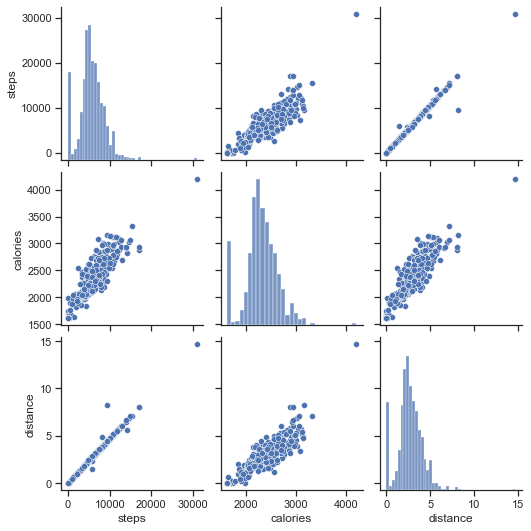

```python
#pair plot for quick coorelation analysis
sns.set_theme(style="ticks")
sns.pairplot(combined_all)
```

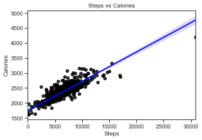

```python
sns.regplot(x="steps", y="calories", data=combined_all, scatter_kws={"color":"black"}, line_kws={"color":"blue"})
plt.title("Steps vs Calories")
plt.xlabel("Steps")
plt.ylabel("Calories")
plt.show()
```